# Assignment 6: Visualization - Aesthetic Mapping

*How to do it?*:

- Open the Rmarkdown file of this assignment (link) in Rstudio.
- Right under each **question**, insert a code chunk (you can use the hotkey `Ctrl + Alt + I` to add a code chunk) and code the solution for the question.
- `Knit` the rmarkdown file (hotkey: `Ctrl + Alt + K`) to export an html.
- Publish the html file to your Githiub Page.

*Submission*: Submit the link on Github of the assignment to Canvas.

### Questions on Your Selected Data

Choose a dataset and produce the following types of plots and comment on each plot. Plots should be meaningful. If you use the data we used in class, make sure the plots are not the same as the ones in the slides.

```r
library(tidyverse)
```

```r
library(ggplot2)
df <- read_csv("C:/Users/student/Downloads/2019WH.csv")
df <- df %>%
  mutate(Country = as.character(Country))
```

1. For one continuous variable:

   First I had to create a categorical variable because the data set only had one, which was country, which there was far too many of. I split healthy life expectancy into 2 groups; above and below average.

   ```r
   df <- df %>%
     mutate(
       Healthylifegroup = if_else(
         Healthy_life_expectancy > mean(Healthy_life_expectancy, na.rm = TRUE),
         "Above Average",
         "Below Average"
       )
     )
   ```

- Density

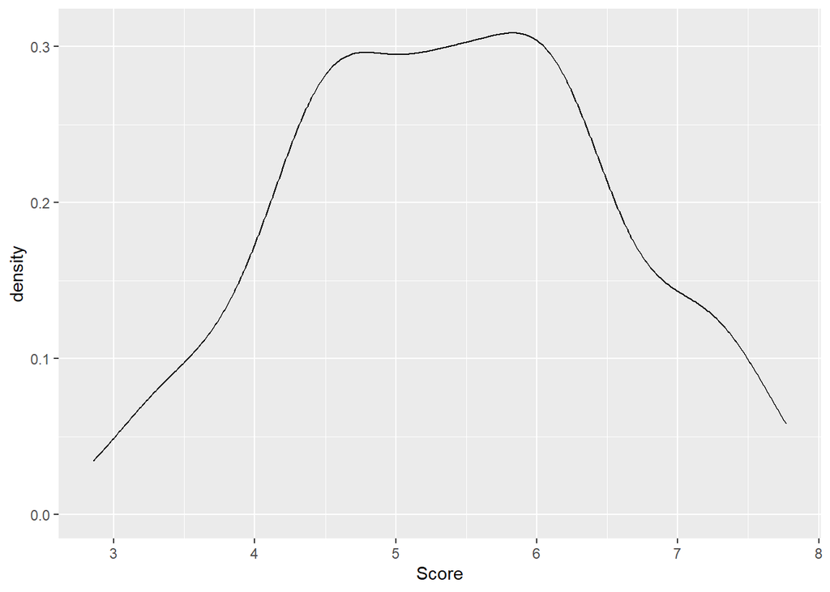

  ```r
  df %>% ggplot()+
    geom_density(mapping = aes(x = Score))
  ```

  Most countries fall towards the average happiness as shown here. A slight left skew shows that its more likely countries report high levels of happiness then low.
- Histogram

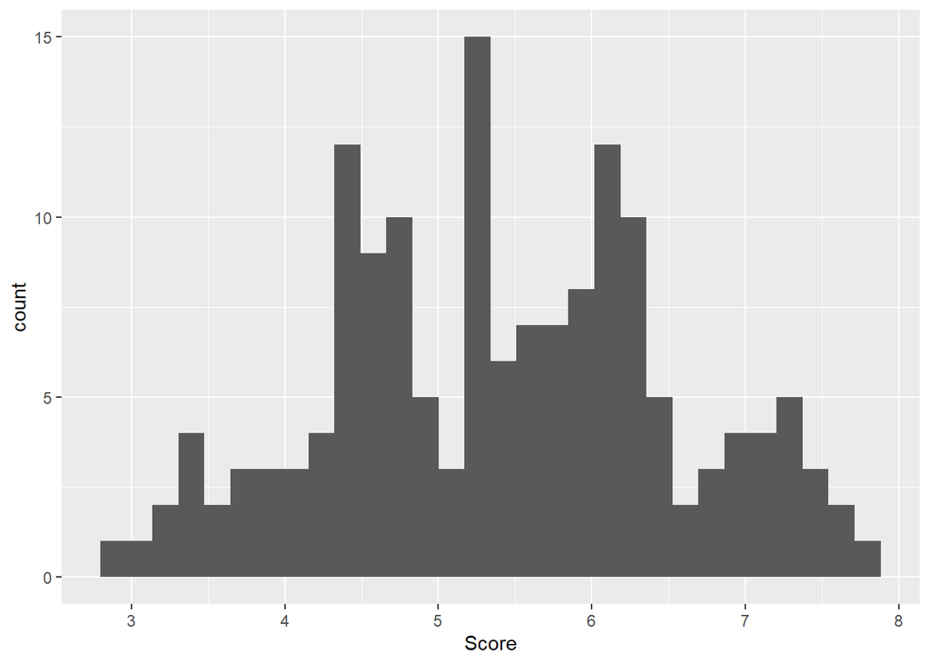

  ```r
  df %>% ggplot()+
    geom_histogram(mapping = aes(x = Score))
  ```

  Very similar to the last one. The histogram does show clunky peaks which can indicate some countries have similar profiles.
- Boxplot

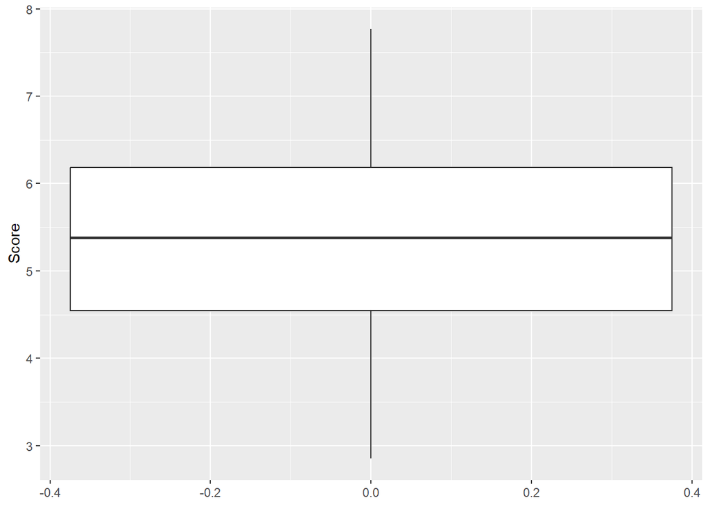

  ```r
  df %>%
    ggplot() +
    geom_boxplot(aes(y = Score))
  ```

The plot shows that happiness is very centered around the center values.

2. For one categorical variable
- Barplot

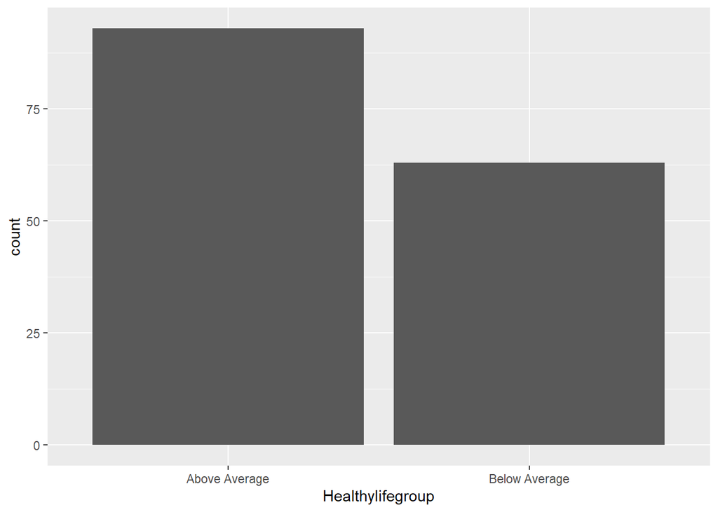

  ```r
  df %>% ggplot()+
    geom_bar(mapping = aes(x = Healthylifegroup))
  ```

When put into a categorical value, healthy life expectancy is shown to have a majority of their countries to be above average. But I just made this categorical variable to be a split above and below the mean. So this shows that their is a left skew because their must be a lot of very low values dragging down the data.

3. For two continuous variables
- Scatter Plot

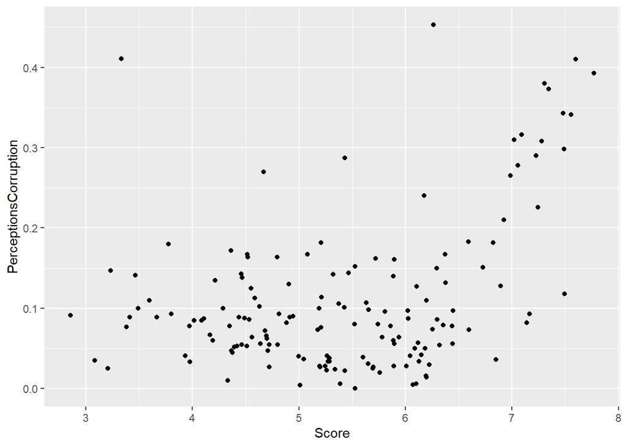

  ```r
  df <- read_csv("C:/Users/student/Downloads/2019WH.csv")
  df %>% ggplot()+geom_point(aes(x=Score, y=PerceptionsCorruption))
  ```

  The graph does appear to show some correlation between corruption and happiness score. It seems to be fairly noisy in countries below 6.5 happiness though.
- Line Plot

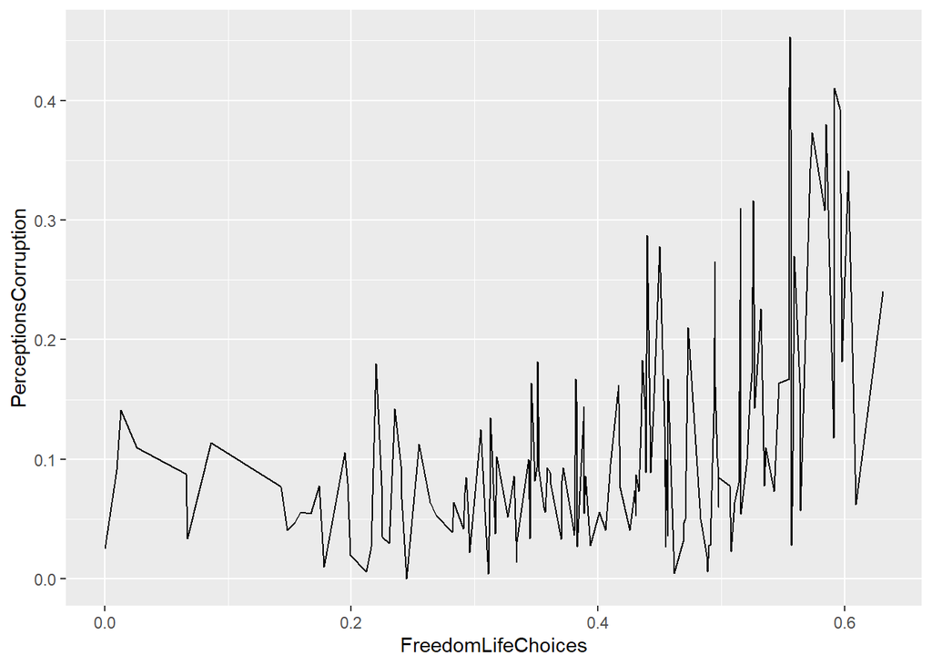

  ```r
  df %>% ggplot()+geom_line(aes(x=FreedomLifeChoices, y=PerceptionsCorruption))
  ```

  I thought this one would be very interesting because freedom comes at a cost. There does appear to be some correlation between freedom and corruption, although lots of variance.
- Smooth Plot

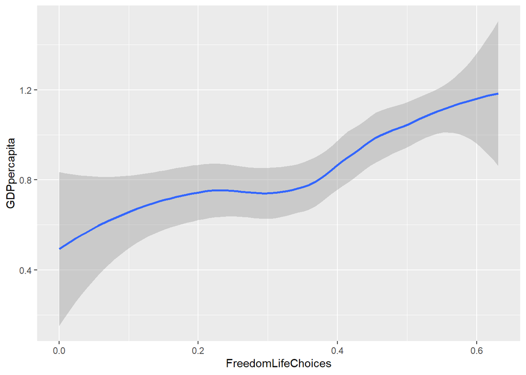

  ```r
  df <- read_csv("C:/Users/student/Downloads/2019WH.csv")
  df %>% ggplot()+geom_smooth(aes(x=FreedomLifeChoices, y=GDPpercapita))
  ```

Freedom to make life choices has a distinct relationship with GDP

4. For one continuous + one categorical variables
- Density

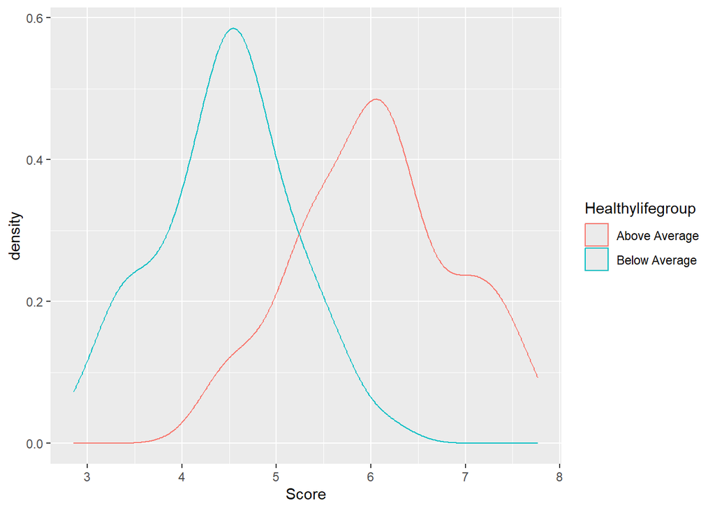

  ```r
  df <- df %>%
    mutate(
      Healthylifegroup = if_else(
        Healthy_life_expectancy > mean(Healthy_life_expectancy, na.rm = TRUE),
        "Above Average",
        "Below Average"
      )
    )

  df %>% ggplot()+
    geom_density(mapping = aes(x = Score, color = Healthylifegroup))
  ```

  This shows that happier countries tend to be healthier, no surprise there.
- BoxPlot

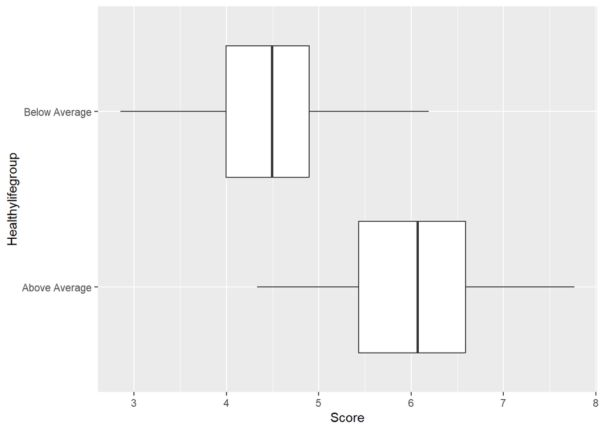

  ```r
  df %>% ggplot()+
    geom_boxplot(mapping = aes(x = Score, y = Healthylifegroup))
  ```

5. For two categorical variables: barplot

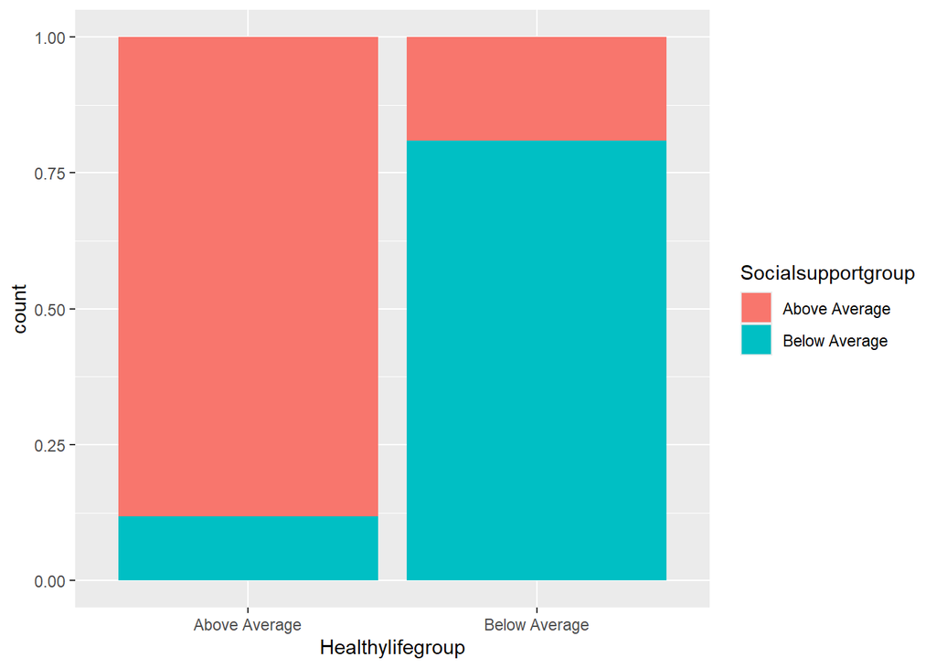

   ```r
   df <- read_csv("C:/Users/student/Downloads/2019WH.csv")
   df <- df %>%
     mutate(
       Socialsupportgroup = if_else(
         Socialsupport > mean(Socialsupport, na.rm = TRUE),
         "Above Average",
         "Below Average"
       )
     )
   df <- df %>%
     mutate(
       Healthylifegroup = if_else(
         Healthy_life_expectancy > mean(Healthy_life_expectancy, na.rm = TRUE),
         "Above Average",
         "Below Average"
       )
     )
   df %>% ggplot()+
     geom_bar(mapping=aes(x=Healthylifegroup, fill=Socialsupportgroup), position = 'fill')
   ```

   Countries with above average healthy life scores usually have above average scores in social support, and the same goes for the reverse, showing a strong relationship between the two.
6. A plot that contains three variables

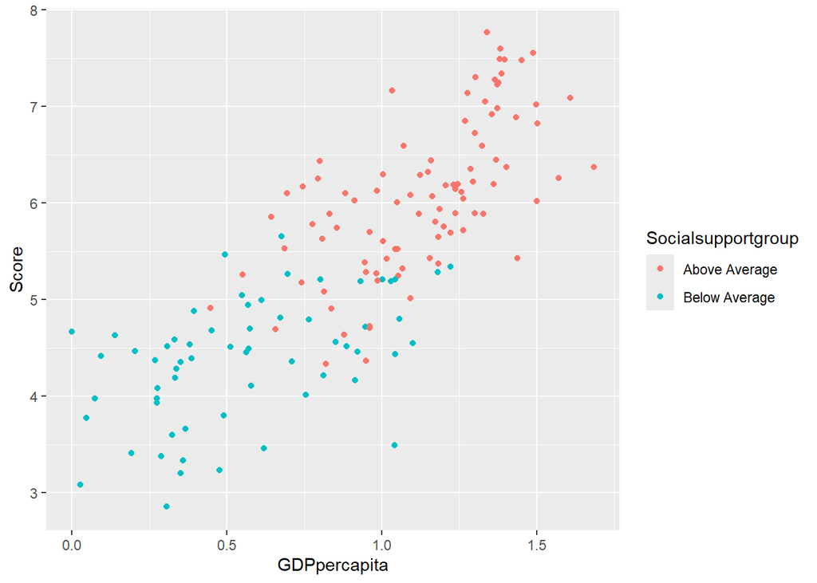

```r
df %>% ggplot() + geom_point(aes(x=GDPpercapita, y=Score, color = Socialsupportgroup))
```

Not only does GDP have a strong correlation with happiness score, social support seems to fit really well into the graph as well, as it separates the two very well and fits in the strong correlation. As you would expect, both GDP and social support play a role in happiness score.